# Analysis Replication

```r
f <-"C:/Users/Audrey/Desktop/Nunes_2015(1).csv"
d <- read.csv(f, header = TRUE)
head(d)
```

```
##                         Species Reg.spec.no ID..tank. Duration
## 1 Palmaria palmata (macroalgae)      145771         4        0
## 2 Palmaria palmata (macroalgae)      145771         8        0
## 3 Palmaria palmata (macroalgae)      145771        12        0
## 4 Palmaria palmata (macroalgae)      145771        16        0
## 5 Palmaria palmata (macroalgae)      145771        24        0
## 6 Palmaria palmata (macroalgae)      145771        27        0
##           Treat ID..system.      Resp.O2      NPP.O2     GPP.O2 Position
## 1 pCO2=2000 ppm          NA -0.006649616 0.023401535 0.03005115
## 2 pCO2=2000 ppm          NA -0.019921316 0.049570815 0.06949213
## 3 pCO2=2000 ppm          NA -0.024742931 0.040681234 0.06542417
## 4 pCO2=2000 ppm          NA -0.067156863 0.055169340 0.12232620
## 5 pCO2=2000 ppm          NA -0.041879252 0.031420068 0.07329932
## 6 pCO2=2000 ppm          NA -0.021737726 0.000484496 0.02222222
##   ID..algae. DMSP w..mm. h..mm. Area..cm..2. X.NO2....Âµmol.l.
```

[output cut: 90 more lines]

```r
#this dataframe contains only values from the P. palmata species. I separated them because the paper states that each experiment and analysis for the 2 species was done separately.
d1 <- data.frame(d[1:227,])
d1
```

```
##                               Species Reg.spec.no ID..tank. Duration
## 1       Palmaria palmata (macroalgae)      145771         4        0
## 2       Palmaria palmata (macroalgae)      145771         8        0
## 3       Palmaria palmata (macroalgae)      145771        12        0
## 4       Palmaria palmata (macroalgae)      145771        16        0
## 5       Palmaria palmata (macroalgae)      145771        24        0
## 6       Palmaria palmata (macroalgae)      145771        27        0
## 7       Palmaria palmata (macroalgae)      145771         2        0
## 8       Palmaria palmata (macroalgae)      145771         6        0
## 9       Palmaria palmata (macroalgae)      145771        22        0
## 10      Palmaria palmata (macroalgae)      145771        25        0
## 11      Palmaria palmata (macroalgae)      145771        26        0
## 12      Palmaria palmata (macroalgae)      145771         4        4
## 13      Palmaria palmata (macroalgae)      145771         5        4
## 14      Palmaria palmata (macroalgae)      145771         8        4
```

[output cut: 3633 more lines]

```r
#this dataframe contains only values from S. latissima
d2 <- data.frame(d[228:386,])
d2
```

```
##                               Species Reg.spec.no ID..tank. Duration
## 228 Saccharina latissima (macroalgae)      234483        14        0
## 229 Saccharina latissima (macroalgae)      234483        16        0
## 230 Saccharina latissima (macroalgae)      234483        17        0
## 231 Saccharina latissima (macroalgae)      234483         3        0
## 232 Saccharina latissima (macroalgae)      234483         7        0
## 233 Saccharina latissima (macroalgae)      234483        10        0
## 234 Saccharina latissima (macroalgae)      234483        15        0
## 235 Saccharina latissima (macroalgae)      234483        18        0
## 236 Saccharina latissima (macroalgae)      234483        13        4
## 237 Saccharina latissima (macroalgae)      234483        14        4
## 238 Saccharina latissima (macroalgae)      234483        16        4
## 239 Saccharina latissima (macroalgae)      234483        17        4
## 240 Saccharina latissima (macroalgae)      234483         3        4
## 241 Saccharina latissima (macroalgae)      234483         7        4
```

[output cut: 2545 more lines]

# Analysis 1: Determining the most useful model for NPP

## Assessment of Normality

Net Primary Productivity in this paper was determined as the difference in dissolved oxygen concentrations between measurements taken at the start of the experiment and at the end of the light incubation period. First, as in the paper, I used a qqnorm plot along with a histogram to show that the data for NPP is clearly not linear or normal.

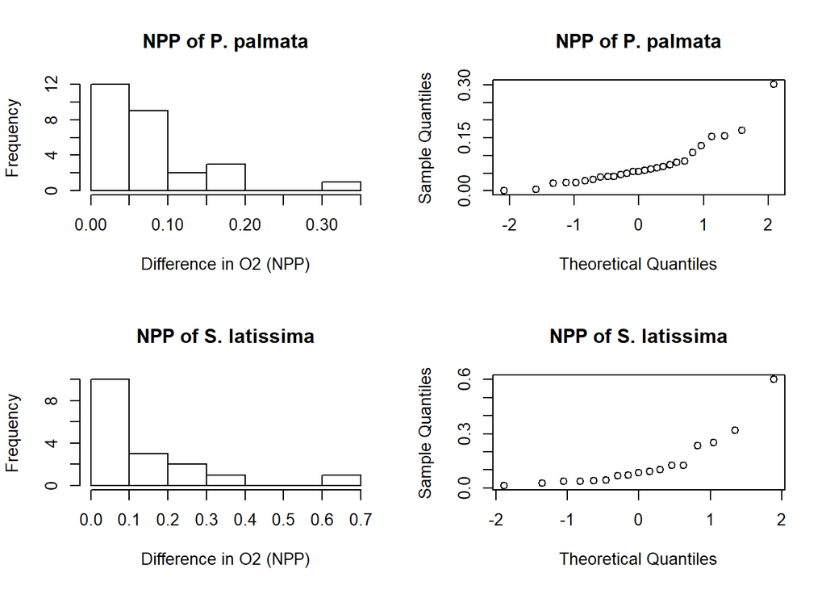

```r
par(mfrow = c(2,2))
hist(d1$NPP.O2, xlab = "Difference in O2 (NPP)", main = "NPP of P. palmata")
qqnorm(d1$NPP.O2, main = "NPP of P. palmata")
hist(d2$NPP.O2, xlab = "Difference in O2 (NPP)", main = "NPP of S. latissima")
qqnorm(d2$NPP.O2, main = "NPP of S. latissima")
```

## Comparing possible models using AIC and log likelihoods

In the paper, it seemed to me that the indicator of ‘OA’ was the pH (Potentiometric) measurement and not the pH calculated by seacarb though this was not made clear. Therefore, I used the potentiometric values for my analysis. The ‘Treat’ column may also have been used for OA as this shows the concentration of CO2 in each sample, but since these values matched up with the pH values, I used the pH values instead.

### Models for P. palmata NPP

```r
#all of the possible models that were considered in the study
#Duration is Time and Potentiometric.pH is OA as they appear in the paper.

m1 <- lm(data = d1, NPP.O2 ~ Duration * Potentiometric.pH)
m2 <- lm(data = d1, NPP.O2 ~ Duration + Potentiometric.pH)
m3 <- lm(data = d1, NPP.O2 ~ Duration)
m4 <- lm(data = d1, NPP.O2 ~ Potentiometric.pH)
m5 <- lm(data = d1, NPP.O2 ~ 1)
```

```r
library(MASS)
stepAIC(m1, direction = "both")
```

```
## Start:  AIC=-150.22
## NPP.O2 ~ Duration * Potentiometric.pH
##
##                              Df  Sum of Sq      RSS     AIC
## - Duration:Potentiometric.pH  1 0.00089563 0.077874 -151.91
## <none>                                     0.076979 -150.22
##
## Step:  AIC=-151.91
## NPP.O2 ~ Duration + Potentiometric.pH
##
##                              Df Sum of Sq      RSS     AIC
## <none>                                    0.077874 -151.91
## + Duration:Potentiometric.pH  1 0.0008956 0.076979 -150.22
## - Potentiometric.pH           1 0.0129256 0.090800 -149.76
## - Duration                    1 0.0213889 0.099263 -147.36
```

```
##
## Call:
## lm(formula = NPP.O2 ~ Duration + Potentiometric.pH, data = d1)
##
## Coefficients:
##       (Intercept)           Duration  Potentiometric.pH
##          -2.27980            0.01445            0.29193
```

# Analysis 2: Finding the best model for respiration

Respiration values in this paper were taken as the difference in dissolved oxygen between measurements taken at the start of the experiment and the end of the dark incubation period.

The respiration analysis was done in a similar manner to the NPP analysis and again the first step was to use the qq plot to determine if the data was normal, and it was not.

[figure not shown]

```r
par(mfrow = c(2,2))
hist(d1$Resp.O2, xlab = "Change in Dissolved O2 (Respiration)", main = "Respiration of P. palmata")
qqnorm(d1$Resp.O2, main = "Net Primary Productivity")
hist(d2$Resp.O2, xlab = "Change in Dissolved O2 (Respiration)", main = "Respiration of S. latissima")
qqnorm(d2$Resp.O2, main = "Net Primary Productivity")
```